# IDG-DREAM Round 2 Ensemble Analysis

08 July, 2019

Round 2 of the IDG-DREAM Challenge gave participants two opportunities to predict 394 Kd values between 25 compounds and 207 kinases.

First, import packages, scoring functions, and challenge data.

#Spearman ensemble

Let’s rank the submissions, taking the best submission from R2 for each team (54 submissions total, then).

```r
best_spearman_by_team <- leaderboard %>%
  group_by(submitterId) %>%
  top_n(1, spearman) %>%
  ungroup() %>%
  arrange(-spearman) %>%
  add_column(rank = group_indices(., -spearman)) %>%
  mutate(objectId = as.character(objectId))

paths <- map_chr(best_spearman_by_team$id, get_path)
names(paths) <- best_spearman_by_team$objectId
```

Then we map all of these ranked prediction files and gather the prediction values into one tidy data frame.

```r
preds <- pmap(.l = list(path = paths, renameColname = 'pKd_[M]_pred', newName = names(paths)), .f = challengescoring:::.read_and_rename) %>%
  purrr::reduce(left_join) %>%
  tidyr::gather(objectId, pred, -Compound_SMILES, -Compound_InchiKeys, -Compound_Name, -UniProt_Id, -Entrez_Gene_Symbol, -DiscoveRx_Gene_Symbol) %>%
  left_join(select(best_spearman_by_team, objectId, rank))
```

Then, we run apply across the number of ranks (1:54), and iterate over each rank, filtering the data for that rank or better, grouping by each compound-kinase pair, and summarizing the prediction by taking the median prediction for each compound-kinase pair. We repeat this for each rank, and then reduce to get a data frame where median_ensemble_1 is the median predictions for rank 1, median_ensemble_2 is the median prediction for each compound-kinase pair for ranks 1:2, and so forth through 1:54.

```r
median_preds_sp <- lapply(unique(preds$rank), function(i){
   colname <- paste0('spearman_median_ensemble_',i)
   foo <- preds %>%
     filter(rank <= i) %>%
     group_by(Compound_SMILES, Compound_InchiKeys, Compound_Name, UniProt_Id, Entrez_Gene_Symbol,
              DiscoveRx_Gene_Symbol) %>%
     summarize(!!colname := median(pred)) %>%
     ungroup()
   foo
 }) %>% reduce(left_join)
```

Now, we need to figure out which ensemble is the best of the 54 we created.

```r
median_test <- left_join(median_preds_sp, gold)

median_results_spearman <- apply(median_test %>% select(7:(ncol(median_test)-1),`pKd_[M]`), 2, spearman_py,
                                 gold = median_test$`pKd_[M]`) %>%
  as.data.frame() %>%
  rownames_to_column("ensemble_model") %>%
  filter(ensemble_model != "pKd_[M]") %>%
  mutate(iteration = str_extract(ensemble_model, "[:digit:]+")) %>%
  mutate(ensemble_model = str_extract(ensemble_model, "[:alpha:]+_[:alpha:]+_[:alpha:]+"))
```

Let’s try some other aggregation methods:

ranked (weighted mean) spearman:

```r
rank_preds_sp <- lapply(unique(preds$rank), function(i){
   colname <- paste0('spearman_rank_ensemble_',i)
   foo <- preds %>%
     filter(rank <= i) %>%
     mutate(predrankweight = (pred*(55-rank))/sum((55-i):54)) %>%
     group_by(Compound_SMILES, Compound_InchiKeys, Compound_Name, UniProt_Id, Entrez_Gene_Symbol,
              DiscoveRx_Gene_Symbol) %>%
     summarize(!!colname := sum(predrankweight)) %>%
     ungroup()
   foo
 }) %>% reduce(left_join)

rank_test <- left_join(rank_preds_sp, gold)

rank_results_spearman <- apply(rank_test %>% select(7:(ncol(rank_test)-1),`pKd_[M]`), 2, spearman_py,
                                 gold = rank_test$`pKd_[M]`) %>%
  as.data.frame() %>%
  rownames_to_column("ensemble_model") %>%
  filter(ensemble_model != "pKd_[M]") %>%
  mutate(iteration = str_extract(ensemble_model, "[:digit:]+")) %>%
  mutate(ensemble_model = str_extract(ensemble_model, "[:alpha:]+_[:alpha:]+_[:alpha:]+"))
```

mean:

```r
mean_preds_sp <- lapply(unique(preds$rank), function(i){
   colname <- paste0('spearman_mean_ensemble_',i)
   foo <- preds %>%
     filter(rank <= i) %>%
     group_by(Compound_SMILES, Compound_InchiKeys, Compound_Name, UniProt_Id, Entrez_Gene_Symbol,
              DiscoveRx_Gene_Symbol) %>%
     summarize(!!colname := mean(pred)) %>%
     ungroup()
   foo
 }) %>% reduce(left_join)

mean_test <- left_join(mean_preds_sp, gold)

mean_results_spearman <- apply(mean_test %>% select(7:(ncol(mean_test)-1),`pKd_[M]`), 2, spearman_py,
                                 gold = mean_test$`pKd_[M]`) %>%
  as.data.frame() %>%
  rownames_to_column("ensemble_model") %>%
  filter(ensemble_model != "pKd_[M]") %>%
  mutate(iteration = str_extract(ensemble_model, "[:digit:]+")) %>%
  mutate(ensemble_model = str_extract(ensemble_model, "[:alpha:]+_[:alpha:]+_[:alpha:]+"))
```

calculate rmse for the mean ensemble for paper

```r
mean_preds_rm_paper <- lapply(unique(preds$rank), function(i){
   colname <- paste0('rmse_mean_ensemble_',i)
   foo <- preds %>%
     filter(rank <= i) %>%
     group_by(Compound_SMILES, Compound_InchiKeys, Compound_Name, UniProt_Id, Entrez_Gene_Symbol,
              DiscoveRx_Gene_Symbol) %>%
     summarize(!!colname := mean(pred)) %>%
     ungroup()
   foo
 }) %>% reduce(left_join)

mean_test <- left_join(mean_preds_rm_paper, gold)

mean_results_rmse_paper <- apply(mean_test %>% select(7:(ncol(mean_test)-1),`pKd_[M]`), 2, rmse_py,
                                 gold = mean_test$`pKd_[M]`) %>%
  as.data.frame() %>%
  rownames_to_column("ensemble_model") %>%
  filter(ensemble_model != "pKd_[M]") %>%
  mutate(iteration = str_extract(ensemble_model, "[:digit:]+")) %>%
  mutate(ensemble_model = str_extract(ensemble_model, "[:alpha:]+_[:alpha:]+_[:alpha:]+"))
```

Now stick them all together into one data frame and plot them to get an idea of relative performance.

```r
ensemble_scores <- bind_rows(median_results_spearman, mean_results_spearman, rank_results_spearman, mean_results_rmse_paper)  %>%
  set_names(c("ensemble_model", "score", "iteration")) %>%
  mutate(iteration = as.numeric(iteration)) %>%
  mutate(label = case_when(iteration == 1 & ensemble_model == "spearman_mean_ensemble"  ~ "Q.E.D.",
                           iteration == 2 & ensemble_model == "spearman_mean_ensemble"  ~ "1 + Gregory Koytiger",
                           iteration == 3 & ensemble_model == "spearman_mean_ensemble" ~ "2 + AI Winter is Coming",
                           iteration == 4 & ensemble_model == "spearman_mean_ensemble" ~ "3 + Oliver Labayle",
                           iteration > 4 | ensemble_model != "spearman_mean_ensemble" ~ ""))
```

Cutoff any scores <0.45

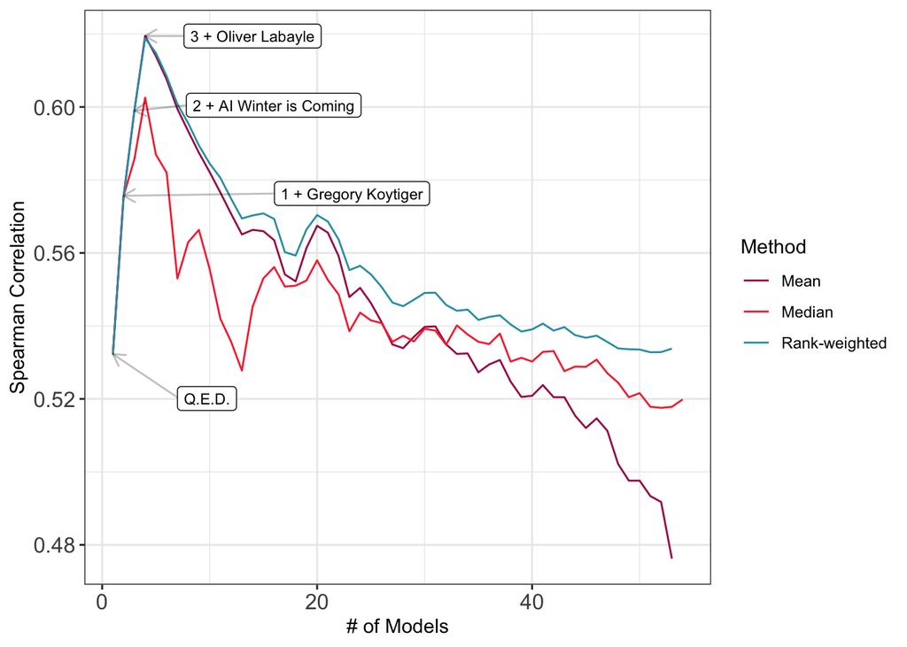

```r
ggplot(data = ensemble_scores %>%
         filter(grepl("*spearman*", ensemble_model)) %>%
         filter(score > 0.45)) +
  geom_line(aes(x= iteration, y = score, color = ensemble_model)) +
  ggrepel::geom_label_repel(aes(x= iteration, y = score, label = label), nudge_x = 10, size = 3, segment.alpha = 0.25, arrow = grid::arrow(type = "open", length = unit(0.5, "lines")), alpha = 1, force = 100) +
  scale_color_manual(values = c("#AA1155","#F8333C","#2B9EB3"),
                     name = "Method",
                     labels = c("Mean", "Median", "Rank-weighted")) +
  theme_bw() +
  labs(x = "# of Models", y = "Spearman Correlation") +
  theme(axis.text = element_text(size = 12))
```

Include all scores

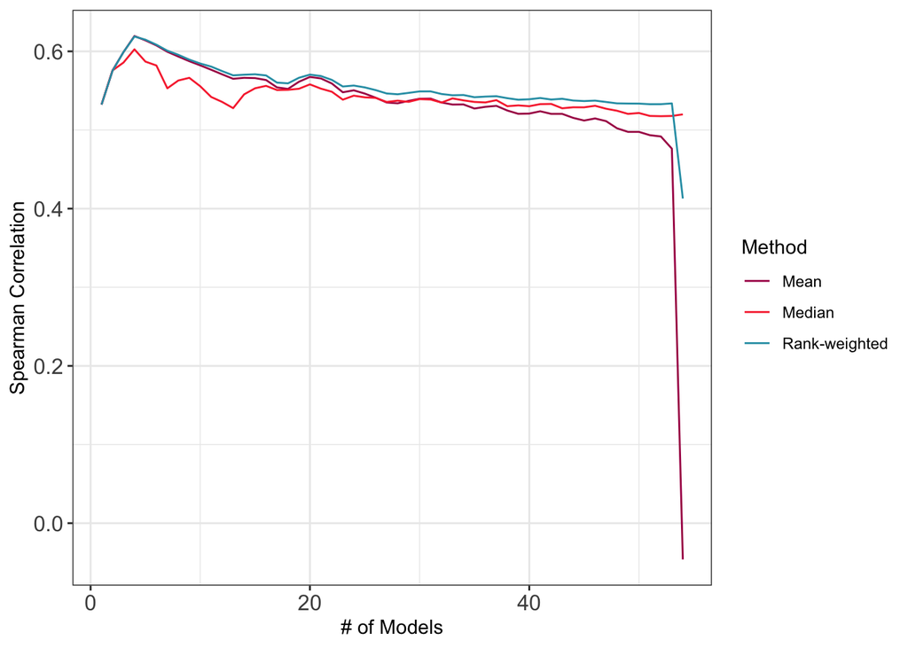

```r
ggplot(data = ensemble_scores %>%
         filter(grepl("*spearman*", ensemble_model)))  +
  geom_line(aes(x= iteration, y = score, color = ensemble_model)) +
  scale_color_manual(values = c("#AA1155","#F8333C","#2B9EB3"),
                     name = "Method",
                     labels = c("Mean", "Median", "Rank-weighted")) +
  theme_bw() +
  labs(x = "# of Models", y = "Spearman Correlation") +
  theme(axis.text = element_text(size = 12))
```

main paper figure

Cutoff any scores <0.45

spearman and RMSE for same model

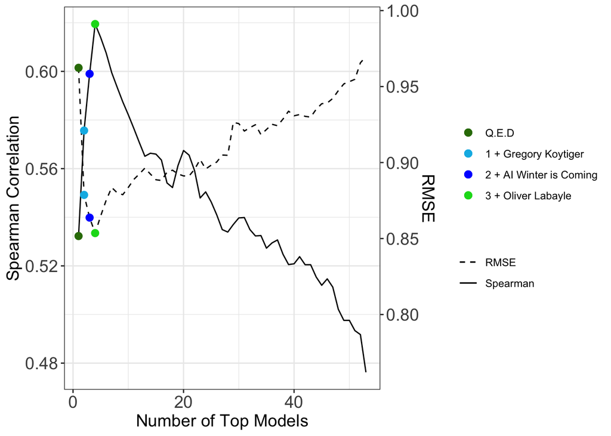

```r
ensemble_scores_pap <- bind_rows( mean_results_spearman,mean_results_rmse_paper)  %>%
  set_names(c("ensemble_model", "score", "iteration")) %>%
  mutate(iteration = as.numeric(iteration)) %>%
  mutate(label = case_when(iteration == 1  ~ "Q.E.D.",
                           iteration == 2  ~ "1 + Gregory Koytiger",
                           iteration == 3  ~ "2 + AI Winter is Coming",
                           iteration == 4  ~ "3 + Oliver Labayle",
                           iteration > 4 ~ NA_character_)) %>%
  mutate(ensemble_model_type = case_when(grepl("*spearman*", ensemble_model) ~ "Spearman",
                           grepl("*rmse*", ensemble_model)  ~ "RMSE"))

scal_fact <- 1.6

ggplot(data = ensemble_scores_pap %>%
         filter(grepl("*spearman_mean*", ensemble_model)) %>%
         filter(score > 0.45))+
  geom_line(data = ensemble_scores_pap %>%
         filter(grepl("*rmse_mean*", ensemble_model)) %>%
         filter(score <2),
         aes(x= iteration, y = score/scal_fact, linetype = ensemble_model_type)) +
  geom_line(aes(x= iteration, y = score, linetype = ensemble_model_type)) +
  geom_point(data = ensemble_scores_pap %>%
         filter(grepl("*spearman_mean*", ensemble_model)) %>%
         filter(score > 0.45) %>%
           filter(!is.na(label)),
         aes(x= iteration, y = score, color = forcats::fct_inorder(label)), size = 2.5) +
   geom_point(data = ensemble_scores_pap %>%
         filter(grepl("*rmse_mean*", ensemble_model)) %>%
         filter(score <2) %>%
         filter(!is.na(label)),
         aes(x= iteration, y = score/scal_fact, color = forcats::fct_inorder(label)), size = 2.5) +
  scale_color_manual(values = c("#307905",
                                "#00b8e6",
                                "#0000FF",
                                "#00d91d"),
                     name = "",
                     labels = c("Q.E.D",
                                "1 + Gregory Koytiger",
                                "2 + AI Winter is Coming",
                                '3 + Oliver Labayle')) +
  scale_linetype_manual("",values=c("RMSE"=2,"Spearman"=1)) +
  scale_y_continuous(sec.axis = sec_axis(~.*scal_fact, name = "RMSE")) +
  theme_bw() +
  labs(x = "Number of Top Models", y = "Spearman Correlation") +
  theme(axis.text = element_text(size = 14),
        axis.title = element_text(size = 14))
```

plot the best vs gold standard where the 4th ensemble is the best:

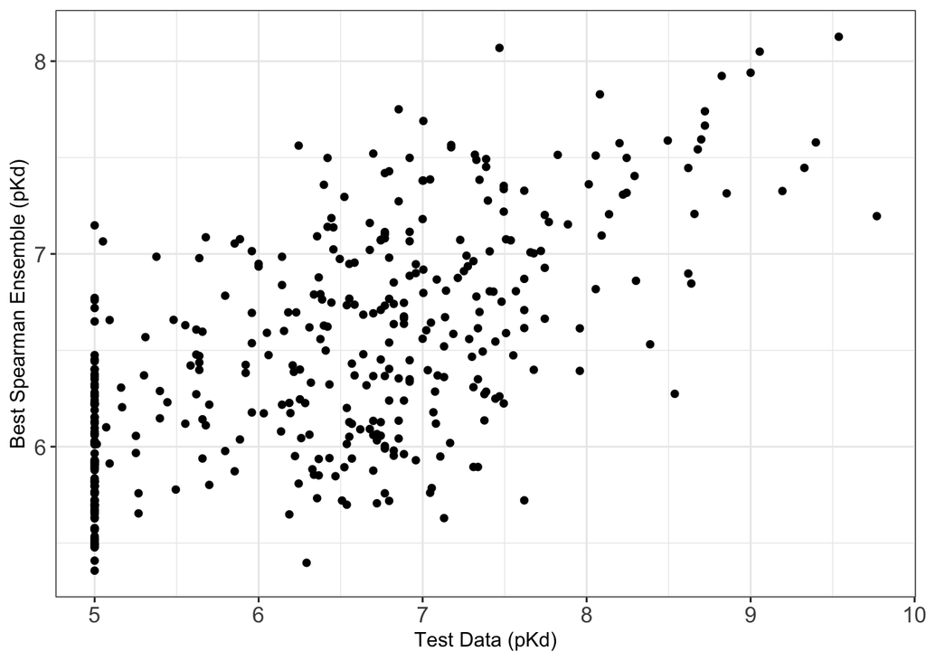

```r
best_ens_vs_gold <- mean_preds_sp %>%
  left_join(gold) %>%
  select(1:6, spearman_mean_ensemble_4, `pKd_[M]`) %>%
  mutate(gold = `pKd_[M]`)

ggplot(data = best_ens_vs_gold) +
  geom_point(aes(x= gold, y= spearman_mean_ensemble_4)) +
  theme_bw() +
  labs(x = "Test Data (pKd)", y = "Best Spearman Ensemble (pKd)") +
  theme(axis.text = element_text(size = 12))
```

##RMSE

And now, we’ll repeat the whole thing but with the other metric, RMSE.

median:

```r
best_rmse_by_team <- leaderboard %>%
  group_by(submitterId) %>%
  top_n(1, -rmse) %>%
  ungroup() %>%
  arrange(-rmse) %>%
  add_column(rank = group_indices(., rmse)) %>%
  mutate(objectId = as.character(objectId))

paths <- map_chr(best_rmse_by_team$id, get_path)
names(paths) <- best_rmse_by_team$objectId

preds <- pmap(.l = list(path = paths, renameColname = 'pKd_[M]_pred', newName = names(paths)), .f = challengescoring:::.read_and_rename) %>%
  purrr::reduce(left_join) %>%
  tidyr::gather(objectId, pred, -Compound_SMILES, -Compound_InchiKeys, -Compound_Name, -UniProt_Id, -Entrez_Gene_Symbol, -DiscoveRx_Gene_Symbol) %>%
  left_join(select(best_rmse_by_team, objectId, rank))

median_preds_rm <- lapply(unique(preds$rank), function(i){
   colname <- paste0('rmse_median_ensemble_',i)
   foo <- preds %>%
     filter(rank <= i) %>%
     group_by(Compound_SMILES, Compound_InchiKeys, Compound_Name, UniProt_Id, Entrez_Gene_Symbol,
              DiscoveRx_Gene_Symbol) %>%
     summarize(!!colname := median(pred)) %>%
     ungroup()
   foo
 }) %>% reduce(left_join)

median_test <- left_join(median_preds_rm, gold)

median_results_rmse <- apply(median_test %>% select(7:(ncol(median_test)-1),`pKd_[M]`), 2, rmse_py,
                                 gold = median_test$`pKd_[M]`) %>%
  as.data.frame() %>%
  rownames_to_column("ensemble_model") %>%
  filter(ensemble_model != "pKd_[M]") %>%
  mutate(iteration = str_extract(ensemble_model, "[:digit:]+")) %>%
  mutate(ensemble_model = str_extract(ensemble_model, "[:alpha:]+_[:alpha:]+_[:alpha:]+"))
```

ranked (weighted mean) RMSE:

```r
rank_preds_rm <- lapply(unique(preds$rank), function(i){
   colname <- paste0('rmse_rank_ensemble_',i)
   foo <- preds %>%
     filter(rank <= i) %>%
     mutate(predrankweight = (pred*(55-rank))/sum((55-i):54)) %>%
     group_by(Compound_SMILES, Compound_InchiKeys, Compound_Name, UniProt_Id, Entrez_Gene_Symbol,
              DiscoveRx_Gene_Symbol) %>%
     summarize(!!colname := sum(predrankweight)) %>%
     ungroup()
   foo
 }) %>% reduce(left_join)

rank_test <- left_join(rank_preds_rm, gold)

rank_results_rmse <- apply(rank_test %>% select(7:(ncol(rank_test)-1),`pKd_[M]`), 2, rmse_py,
                                 gold = rank_test$`pKd_[M]`) %>%
  as.data.frame() %>%
  rownames_to_column("ensemble_model") %>%
  filter(ensemble_model != "pKd_[M]") %>%
  mutate(iteration = str_extract(ensemble_model, "[:digit:]+")) %>%
  mutate(ensemble_model = str_extract(ensemble_model, "[:alpha:]+_[:alpha:]+_[:alpha:]+"))
```

mean:

```r
mean_preds_rm <- lapply(unique(preds$rank), function(i){
   colname <- paste0('rmse_mean_ensemble_',i)
   foo <- preds %>%
     filter(rank <= i) %>%
     group_by(Compound_SMILES, Compound_InchiKeys, Compound_Name, UniProt_Id, Entrez_Gene_Symbol,
              DiscoveRx_Gene_Symbol) %>%
     summarize(!!colname := mean(pred)) %>%
     ungroup()
   foo
 }) %>% reduce(left_join)

mean_test <- left_join(mean_preds_rm, gold)

mean_results_rmse <- apply(mean_test %>% select(7:(ncol(mean_test)-1),`pKd_[M]`), 2, rmse_py,
                                 gold = mean_test$`pKd_[M]`) %>%
  as.data.frame() %>%
  rownames_to_column("ensemble_model") %>%
  filter(ensemble_model != "pKd_[M]") %>%
  mutate(iteration = str_extract(ensemble_model, "[:digit:]+")) %>%
  mutate(ensemble_model = str_extract(ensemble_model, "[:alpha:]+_[:alpha:]+_[:alpha:]+"))
```

plot it all:

```r
ensemble_scores <- bind_rows(median_results_rmse, mean_results_rmse, rank_results_rmse)  %>%
  set_names(c("ensemble_model", "score", "iteration")) %>%
  mutate(iteration = as.numeric(iteration)) %>%
  mutate(label = case_when(iteration == 1 & ensemble_model == "rmse_rank_ensemble"  ~ "Gregory Koytiger",
                           iteration == 2 & ensemble_model == "rmse_rank_ensemble"  ~ "1 + AI Winter is Coming",
                           iteration == 3 & ensemble_model == "rmse_rank_ensemble" ~ "2 + DMIS_DK",
                           iteration == 4 & ensemble_model == "rmse_rank_ensemble" ~ "3 + ljwyc",
                           iteration == 5 & ensemble_model == "rmse_rank_ensemble" ~ "4 + Q.E.D",
                           iteration > 5 | ensemble_model != "rmse_rank_ensemble" ~ ""))
```

Plot where RMSE <1

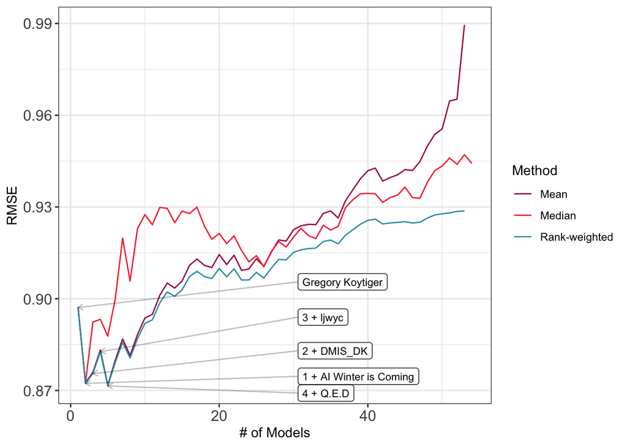

```r
ggplot(data = ensemble_scores %>%
         filter(grepl("*rmse*", ensemble_model)) %>%
         filter(score < 1)) +
  geom_line(aes(x= iteration, y = score, color = ensemble_model)) +
  ggrepel::geom_label_repel(aes(x= iteration, y = score, label = label), size = 3, segment.alpha = 0.25, alpha = 1, direction = "y", ylim =c(0.865,0.92), xlim = c(30,54), force = 20,arrow = grid::arrow(type = "open", length = unit(0.3, "lines"))) +
  scale_color_manual(values = c("#AA1155","#F8333C","#2B9EB3"),
                     name = "Method",
                     labels = c("Mean", "Median", "Rank-weighted")) +
  theme_bw() +
  labs(x = "# of Models", y = "RMSE") +
  theme(axis.text = element_text(size = 12))
```

Plot all no cutoff

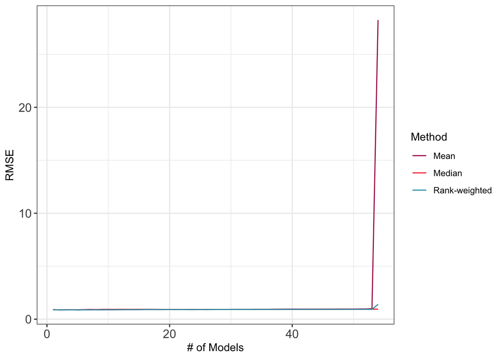

```r
ggplot(data = ensemble_scores %>%
         filter(grepl("*rmse*", ensemble_model))) +
  geom_line(aes(x= iteration, y = score, color = ensemble_model)) +
  scale_color_manual(values = c("#AA1155","#F8333C","#2B9EB3"),
                     name = "Method",
                     labels = c("Mean", "Median", "Rank-weighted")) +
  theme_bw() +
  labs(x = "# of Models", y = "RMSE") +
  theme(axis.text = element_text(size = 12))
```

plot the best vs gold standard, where the 5th ensemble is the best:

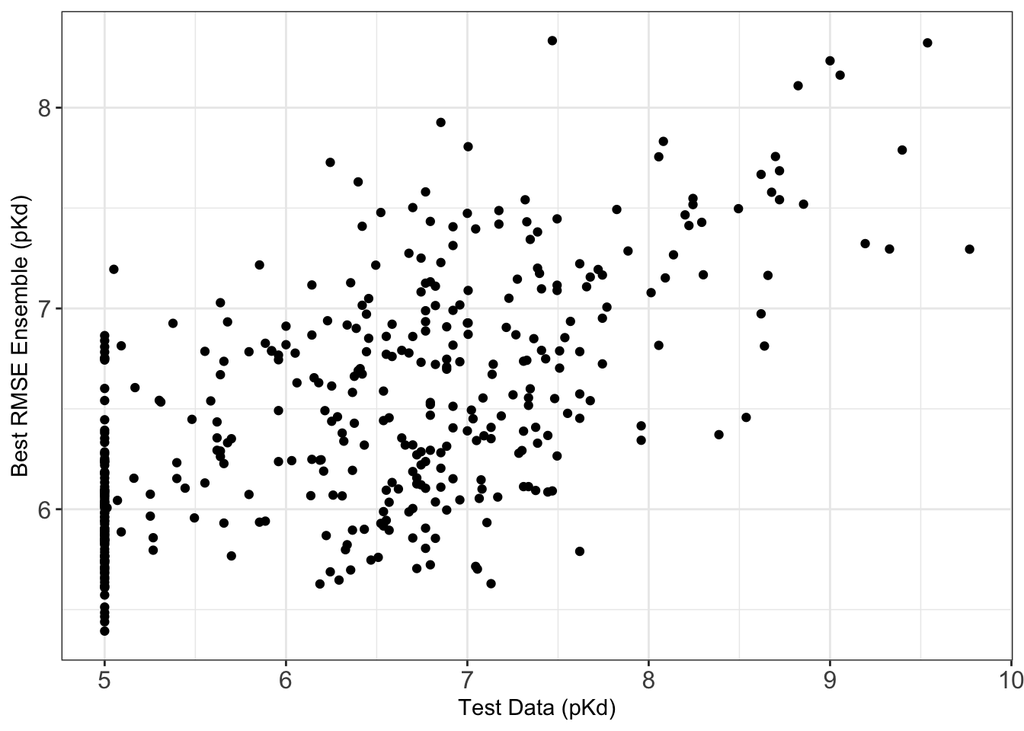

```r
best_ens_vs_gold <- mean_preds_rm %>%
  left_join(gold) %>%
  select(1:6, rmse_mean_ensemble_5, `pKd_[M]`) %>%
  mutate(gold = `pKd_[M]`)

ggplot(data = best_ens_vs_gold) +
  geom_point(aes(x= gold, y= rmse_mean_ensemble_5)) +
  theme_bw() +
  labs(x = "Test Data (pKd)", y = "Best RMSE Ensemble (pKd)") +
  theme(axis.text = element_text(size = 12))
```

The following sections take a considerable amount of time to run so are set `eval=FALSE` by default.

Then, we score all of these predictions using a bootstrap function from the `challengescoring` package. We’ll calculate Bayes factors using the first ‘ensemble’ (i.e. the top method only) as reference for “best” prediction to assess whether it’s substantially different from its neighboring ensembles.

spearman:

```r
computeBayesFactorWhereRefIsNotBest <- function(bootstrapMetricMatrix,
                               refPredIndex,
                               invertBayes){

    M <- as.data.frame(bootstrapMetricMatrix - bootstrapMetricMatrix[,refPredIndex])
    K <- apply(M ,2, function(x) {
      k <- sum(x >= 0)/sum(x < 0)
      if(sum(x >= 0) > sum(x < 0)){
      return(k)
      }else{
      return(1/k)
      }
    })
    if(invertBayes == T){K <- 1/K}
    K[refPredIndex] <- 0

    return(K)
}


ens_spearman_rank_bs <- finalScoring(predictions = rank_preds_sp %>% select(-spearman_rank_ensemble_1),
                         predictionColname = NA,
                         predictionIds = colnames(rank_preds_sp %>% select(-spearman_rank_ensemble_1))[7:58],
                         goldStandard = gold,
                         goldStandardColname = 'pKd_[M]',
                         bestPrediction =  rank_preds_sp %>% select(1:6,spearman_rank_ensemble_1),
                         bestPredictionId = "spearman_rank_ensemble_1",
                         keyColumns = colnames(gold)[1:6],
                         doParallel = TRUE,
                         scoreFun = spearman_py,
                         largerIsBetter = T)

bayesredo <- computeBayesFactorWhereRefIsNotBest(ens_spearman_rank_bs$bootstrappedScores,
                                                 1, F)

tidy_bayes <- tibble('iteration' = colnames(ens_spearman_rank_bs$bootstrappedScores),
                         'bayes' = bayesredo)

tidy_res <- ens_spearman_rank_bs$bootstrappedScores %>%
  as.data.frame %>%
  tidyr::gather(iteration, bootstrappedScore) %>%
  left_join(tidy_bayes) %>%
  mutate(iteration = stringr::str_extract(iteration, "[:digit:]+") %>% as.numeric %>% as.integer) %>%
  left_join(best_spearman_by_team, by = c("iteration" = "rank")) %>%
  left_join(names_df) %>%
  mutate(model = paste0(iteration-1," + ", participant))

ggplot(data = tidy_res) +
  geom_boxplot(aes(x = reorder(model, iteration, fun = mean) , y = bootstrappedScore,
                   color = cut(bayes, c(-1,0, 3, 5,Inf), include.lowest = T, ordered_result = T, right = T)), outlier.shape = NA)+
  scale_color_manual(values = c("#AA1155","#F8333C","#FCAB10","#2B9EB3"),
                     name = "Bayes Factor",
                     labels = c("Reference", "<3","3-5",">5")) +
  labs(x = "# of models", y = "Bootstrapped Spearman") +
  theme_bw() +
  theme(axis.text.x = element_text(size = 7, angle = 55, hjust = 1, vjust = 1))
```

RMSE:

```r
ens_rmse_rank_bs <- finalScoring(predictions = rank_preds_rm %>% select(-rmse_rank_ensemble_1),
                         predictionColname = NA,
                         predictionIds = colnames(rank_preds_rm %>% select(-rmse_rank_ensemble_1))[7:58],
                         goldStandard = gold,
                         goldStandardColname = 'pKd_[M]',
                         bestPrediction =  rank_preds_rm %>% select(1:6,rmse_rank_ensemble_1),
                         bestPredictionId = "rmse_rank_ensemble_1",
                         keyColumns = colnames(gold)[1:6],
                         doParallel = TRUE,
                         scoreFun = rmse_py,
                         largerIsBetter = T)

bayesredo <- computeBayesFactorWhereRefIsNotBest(ens_rmse_rank_bs$bootstrappedScores,
                                                 1, F)

tidy_bayes <- tibble('iteration' = colnames(ens_rmse_rank_bs$bootstrappedScores),
                         'bayes' = bayesredo)

tidy_res <- ens_rmse_rank_bs$bootstrappedScores %>%
  as.data.frame %>%
  tidyr::gather(iteration, bootstrappedScore) %>%
  left_join(tidy_bayes) %>%
  mutate(iteration = stringr::str_extract(iteration, "[:digit:]+") %>% as.numeric %>% as.integer) %>%
  left_join(best_rmse_by_team, by = c("iteration" = "rank")) %>%
  left_join(names_df) %>%
  mutate(model = paste0(iteration-1," + ", participant))

ggplot(data = tidy_res) +
  geom_boxplot(aes(x = reorder(model, iteration, fun = mean) , y = bootstrappedScore,
                   color = cut(bayes, c(-1,0, 3, 5,Inf), include.lowest = T, ordered_result = T, right = T)), outlier.shape = NA)+
  scale_color_manual(values = c("#AA1155","#F8333C","#FCAB10","#2B9EB3"),
                     name = "Bayes Factor",
                     labels = c("Reference", "<3","3-5",">5")) +
  labs(x = "# of models", y = "Bootstrapped RMSE") +
  theme_bw() +
  theme(axis.text.x = element_text(size = 7, angle = 55, hjust = 1, vjust = 1))
```

```r
write_csv(mean_preds_sp,"spearman_mean_ensemble_models.csv")
write_csv(mean_preds_rm,"rmse_mean_ensemble_models.csv")
write_csv(median_preds_sp,"spearman_median_ensemble_models.csv")
write_csv(median_preds_rm,"rmse_median_ensemble_models.csv")
write_csv(rank_preds_sp,"spearman_rank_ensemble_models.csv")
write_csv(rank_preds_rm,"rmse_rank_ensemble_models.csv")

syn$store(synapse$File("spearman_mean_ensemble_models.csv", parentId = "syn18700959"))
```

[output not shown]

```r
syn$store(synapse$File("rmse_mean_ensemble_models.csv", parentId = "syn18700959"))
```

[output not shown]

```r
syn$store(synapse$File("spearman_median_ensemble_models.csv", parentId = "syn18700959"))
```

[output not shown]

```r
syn$store(synapse$File("rmse_median_ensemble_models.csv", parentId = "syn18700959"))
```

[output not shown]

```r
syn$store(synapse$File("spearman_rank_ensemble_models.csv", parentId = "syn18700959"))
```

[output not shown]

```r
syn$store(synapse$File("rmse_rank_ensemble_models.csv", parentId = "syn18700959"))
```

[output not shown]